# HATLAS-NGP master catalogue

## Preparation of UKIRT Infrared Deep Sky Survey / Large Area Survey (UKIDSS/LAS)

Information about UKIDSS can be found at http://www.ukidss.org/surveys/surveys.html

The catalogue comes from `dmu0_UKIDSS-LAS`.

In the catalogue, we keep:

- The identifier (it's unique in the catalogue);
- The position;
- The stellarity;
- The magnitude for each band in aperture 3 (2 arcsec).
- The hall magnitude is described as the total magnitude.

J band magnitudes are available in two eopchs. We take the first arbitrarily.

The magnitudes are “*Vega like*”. The AB offsets are given by Hewett *et al.* (2016):

| Band | AB offset |
| --- | --- |
| Y | 0.634 |
| J | 0.938 |
| H | 1.379 |
| K | 1.900 |

Each source is associated with an epoch. These range between 2005 and 2007. We take 2006 for the epoch.

```python
from herschelhelp_internal import git_version
print("This notebook was run with herschelhelp_internal version: \n{}".format(git_version()))
```

```
This notebook was run with herschelhelp_internal version:
44f1ae0 (Thu Nov 30 18:27:54 2017 +0000)
```

```python
%matplotlib inline
#%config InlineBackend.figure_format = 'svg'

import matplotlib.pyplot as plt
plt.rc('figure', figsize=(10, 6))

from collections import OrderedDict
import os

from astropy import units as u
from astropy.coordinates import SkyCoord
from astropy.table import Column, Table
import numpy as np

from herschelhelp_internal.flagging import  gaia_flag_column
from herschelhelp_internal.masterlist import nb_astcor_diag_plot, remove_duplicates
from herschelhelp_internal.utils import astrometric_correction, mag_to_flux
```

```python
OUT_DIR =  os.environ.get('TMP_DIR', "./data_tmp")
try:
    os.makedirs(OUT_DIR)
except FileExistsError:
    pass

RA_COL = "las_ra"
DEC_COL = "las_dec"
```

## I - Column selection

```python
#Is the following standard (different names for radec vs mag)?
imported_columns = OrderedDict({
        'SOURCEID': 'las_id',
        'RA': 'las_ra',
        'Dec': 'las_dec',
        'YHALLMAG': 'm_ukidss_y',
        'YHALLMAGERR': 'merr_ukidss_y',
        'YAPERMAG3': 'm_ap_ukidss_y',
        'YAPERMAG3ERR': 'merr_ap_ukidss_y',
        'J_1HALLMAG': 'm_ukidss_j',
        'J_1HALLMAGERR': 'merr_ukidss_j',
        'J_1APERMAG3': 'm_ap_ukidss_j',
        'J_1APERMAG3ERR': 'merr_ap_ukidss_j',
        'HAPERMAG3': 'm_ap_ukidss_h',
        'HAPERMAG3ERR': 'merr_ap_ukidss_h',
        'HHALLMAG': 'm_ukidss_h',
        'HHALLMAGERR': 'merr_ukidss_h',
        'KAPERMAG3': 'm_ap_ukidss_k',
        'KAPERMAG3ERR': 'merr_ap_ukidss_k',
        'KHALLMAG': 'm_ukidss_k',
        'KHALLMAGERR': 'merr_ukidss_k',
        'PSTAR': 'las_stellarity'
    })

catalogue = Table.read(
    "../../dmu0/dmu0_UKIDSS-LAS/data/UKIDSS-LAS_NGP.fits")[list(imported_columns)]
for column in imported_columns:
    catalogue[column].name = imported_columns[column]

#Epochs between 2005 and 2007. Rough average:
epoch = 2006

# Clean table metadata
catalogue.meta = None
```

```
WARNING: UnitsWarning: 'RADIANS' did not parse as fits unit: At col 0, Unit 'RADIANS' not supported by the FITS standard.  [astropy.units.core]
```

```python
# Adding flux and band-flag columns
for col in catalogue.colnames:
    if col.startswith('m_'):

        errcol = "merr{}".format(col[1:])

        # LAS uses a huge negative number for missing values
        catalogue[col][catalogue[col] < -100] = np.nan
        catalogue[errcol][catalogue[errcol] < -100] = np.nan

        # Vega to AB correction
        if col.endswith('y'):
            catalogue[col] += 0.634
        elif col.endswith('j'):
            catalogue[col] += 0.938
        elif col.endswith('h'):
            catalogue[col] += 1.379
        elif col.endswith('k'):
            catalogue[col] += 1.900
        else:
            print("{} column has wrong band...".format(col))

        flux, error = mag_to_flux(np.array(catalogue[col]), np.array(catalogue[errcol]))

        # Fluxes are added in µJy
        catalogue.add_column(Column(flux * 1.e6, name="f{}".format(col[1:])))
        catalogue.add_column(Column(error * 1.e6, name="f{}".format(errcol[1:])))

        # Band-flag column
        if "ap" not in col:
            catalogue.add_column(Column(np.zeros(len(catalogue), dtype=bool), name="flag{}".format(col[1:])))

# TODO: Set to True the flag columns for fluxes that should not be used for SED fitting.
```

```python
catalogue[:10].show_in_notebook()
```

<Table masked=True length=10>

| idx | las_id | las_ra | las_dec | m_ukidss_y | merr_ukidss_y | m_ap_ukidss_y | merr_ap_ukidss_y | m_ukidss_j | merr_ukidss_j | m_ap_ukidss_j | merr_ap_ukidss_j | m_ap_ukidss_h | merr_ap_ukidss_h | m_ukidss_h | merr_ukidss_h | m_ap_ukidss_k | merr_ap_ukidss_k | m_ukidss_k | merr_ukidss_k | las_stellarity | f_ukidss_y | ferr_ukidss_y | flag_ukidss_y | f_ap_ukidss_y | ferr_ap_ukidss_y | f_ukidss_j | ferr_ukidss_j | flag_ukidss_j | f_ap_ukidss_j | … |
| --- | --- | --- | --- | --- | --- | --- | --- | --- | --- | --- | --- | --- | --- | --- | --- | --- | --- | --- | --- | --- | --- | --- | --- | --- | --- | --- | --- | --- | --- | --- |
| 0 | 433795438053 | 206.360659354 | 29.7855932047 | 20.0984 | 0.207045 | 20.7217 | 0.145656 | nan | nan | nan | nan | 20.0392 | 0.138917 | 19.4186 | 0.21079 | 20.3836 | 0.240432 | 20.1323 | 0.39326 | 0.000171409 | 33.1608 | 6.32362 | False | 18.6769 | 2.50558 | nan | nan | False | nan | … |
| 1 | 433795438054 | 206.361234461 | 29.7299660924 | 20.5262 | 0.30814 | 20.8066 | 0.155936 | 20.6763 | 0.179253 | 20.668 | 0.190655 | 20.1888 | 0.157944 | 19.8291 | 0.269121 | nan | nan | nan | nan | 0.000171409 | 22.3632 | 6.34683 | False | 17.2726 | 2.48073 | 19.4751 | 3.2153 | False | 19.6251 | … |
| 2 | 433795438055 | 206.361804481 | 29.7276148576 | 20.8654 | 0.270048 | 20.7487 | 0.147968 | 20.5554 | 0.226177 | 20.4512 | 0.156395 | 20.5749 | 0.224459 | 20.4668 | 0.372434 | nan | nan | nan | nan | 0.999657 | 16.3616 | 4.06952 | False | 18.2196 | 2.48303 | 21.77 | 4.53506 | False | 23.9623 | … |
| 3 | 433795438057 | 206.363384464 | 29.7827067153 | 20.9654 | 0.370267 | 21.0186 | 0.189817 | nan | nan | nan | nan | 20.4649 | 0.204532 | 20.2374 | 0.296498 | nan | nan | nan | nan | 0.486486 | 14.9227 | 5.08906 | False | 14.2088 | 2.48408 | nan | nan | False | nan | … |
| 4 | 433795438058 | 206.361917162 | 29.6159844322 | 19.7907 | 0.197032 | 20.5136 | 0.118256 | 19.7558 | 0.122487 | 20.3115 | 0.135587 | 20.0603 | 0.138222 | 19.033 | 0.173318 | 20.1478 | 0.188964 | 19.5717 | 0.250772 | 9.52581e-06 | 44.0284 | 7.98996 | False | 22.6243 | 2.46419 | 45.4652 | 5.12914 | False | 27.2514 | … |
| 5 | 433795438059 | 206.363582148 | 29.7647248542 | 17.9042 | 0.017478 | 17.8518 | 0.0139216 | 17.9594 | 0.0237724 | 17.908 | 0.0168219 | 18.0485 | 0.0235778 | 18.1199 | 0.0367644 | 18.552 | 0.045628 | 18.5362 | 0.0710826 | 0.999981 | 250.209 | 4.02782 | False | 262.6 | 3.36713 | 237.809 | 5.20687 | False | 249.345 | … |
| 6 | 433795438060 | 206.362717685 | 29.6396639809 | 19.7809 | 0.113873 | 19.7498 | 0.0607979 | 19.4273 | 0.104103 | 19.4432 | 0.0620997 | 19.1494 | 0.0607773 | 19.0219 | 0.090905 | 18.8882 | 0.0603746 | 18.7441 | 0.10025 | 9.52581e-06 | 44.4271 | 4.65956 | False | 45.7168 | 2.56 | 61.5262 | 5.89925 | False | 60.6343 | … |
| 7 | 433795438061 | 206.363122774 | 29.6467782186 | 18.6077 | 0.0310503 | 18.5243 | 0.0224318 | 18.4167 | 0.0337989 | 18.331 | 0.0235453 | 18.2468 | 0.0274628 | 18.3729 | 0.0409548 | 18.5049 | 0.0429273 | 18.5114 | 0.0619389 | 0.999981 | 130.9 | 3.74351 | False | 141.348 | 2.92031 | 156.063 | 4.85824 | False | 168.882 | … |
| 8 | 433795438062 | 206.363569762 | 29.6581647522 | 19.7249 | 0.127328 | 20.2598 | 0.0948532 | 19.6079 | 0.134669 | 19.8476 | 0.0894695 | 20.0179 | 0.1335 | 19.436 | 0.251983 | 19.7324 | 0.129873 | 19.5996 | 0.333055 | 9.52581e-06 | 46.7796 | 5.48602 | False | 28.5824 | 2.49705 | 52.0988 | 6.46205 | False | 41.7774 | … |
| 9 | 433795438063 | 206.364376219 | 29.7717066453 | 16.2387 | 0.00555804 | 16.1877 | 0.0049949 | 16.1142 | 0.00507694 | 16.0551 | 0.00428316 | 15.8968 | 0.00446262 | 15.9414 | 0.00582707 | 16.2847 | 0.00689185 | 16.3237 | 0.00945186 | 0.999981 | 1160.21 | 5.93928 | False | 1216.01 | 5.59424 | 1301.16 | 6.08429 | False | 1373.95 | … |

## II - Removal of duplicated sources

We remove duplicated objects from the input catalogues.

```python
SORT_COLS = ['merr_ap_ukidss_j', 'merr_ap_ukidss_k']
FLAG_NAME = 'las_flag_cleaned'

nb_orig_sources = len(catalogue)

catalogue = remove_duplicates(catalogue, RA_COL, DEC_COL, sort_col=SORT_COLS, flag_name=FLAG_NAME)

nb_sources = len(catalogue)

print("The initial catalogue had {} sources.".format(nb_orig_sources))
print("The cleaned catalogue has {} sources ({} removed).".format(nb_sources, nb_orig_sources - nb_sources))
print("The cleaned catalogue has {} sources flagged as having been cleaned".format(np.sum(catalogue[FLAG_NAME])))
```

```
The initial catalogue had 2517074 sources.
The cleaned catalogue has 2515473 sources (1601 removed).
The cleaned catalogue has 1584 sources flagged as having been cleaned
```

## III - Astrometry correction

We match the astrometry to the Gaia one. We limit the Gaia catalogue to sources with a g band flux between the 30th and the 70th percentile. Some quick tests show that this give the lower dispersion in the results.

```python
gaia = Table.read("../../dmu0/dmu0_GAIA/data/GAIA_NGP.fits")
gaia_coords = SkyCoord(gaia['ra'], gaia['dec'])
```

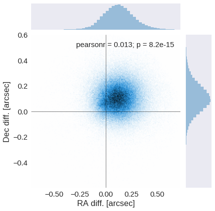

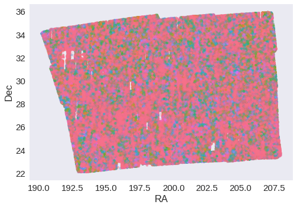

```python
nb_astcor_diag_plot(catalogue[RA_COL], catalogue[DEC_COL],
                    gaia_coords.ra, gaia_coords.dec)
```

```python
delta_ra, delta_dec =  astrometric_correction(
    SkyCoord(catalogue[RA_COL], catalogue[DEC_COL]),
    gaia_coords, near_ra0=True
)

print("RA correction: {}".format(delta_ra))
print("Dec correction: {}".format(delta_dec))
```

```
RA correction: -0.11966463496264623 arcsec
Dec correction: -0.10092503875185344 arcsec
```

```python
catalogue[RA_COL] +=  delta_ra.to(u.deg)
catalogue[DEC_COL] += delta_dec.to(u.deg)
```

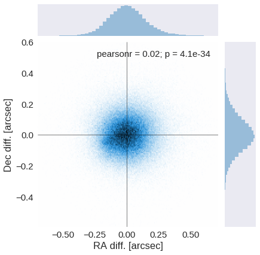

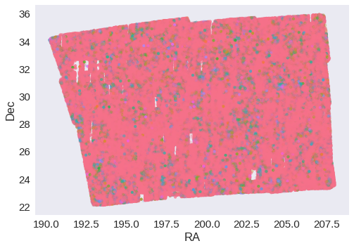

```python
nb_astcor_diag_plot(catalogue[RA_COL], catalogue[DEC_COL],
                    gaia_coords.ra, gaia_coords.dec)
```

## IV - Flagging Gaia objects

```python
catalogue.add_column(
    gaia_flag_column(SkyCoord(catalogue[RA_COL], catalogue[DEC_COL]), epoch, gaia)
)
```

```python
GAIA_FLAG_NAME = "las_flag_gaia"

catalogue['flag_gaia'].name = GAIA_FLAG_NAME
print("{} sources flagged.".format(np.sum(catalogue[GAIA_FLAG_NAME] > 0)))
```

```
374866 sources flagged.
```

## V - Flagging objects near bright stars

# VI - Saving to disk

```python
catalogue.write("{}/UKIDSS-LAS.fits".format(OUT_DIR), overwrite=True)
```